# OpenML

R User Group Meetup, September 2017

[openml.org](http://www.openml.org/)

[figure not shown]

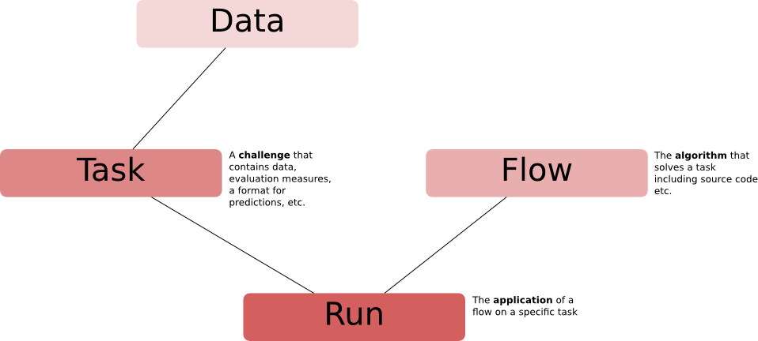

[figure not shown]

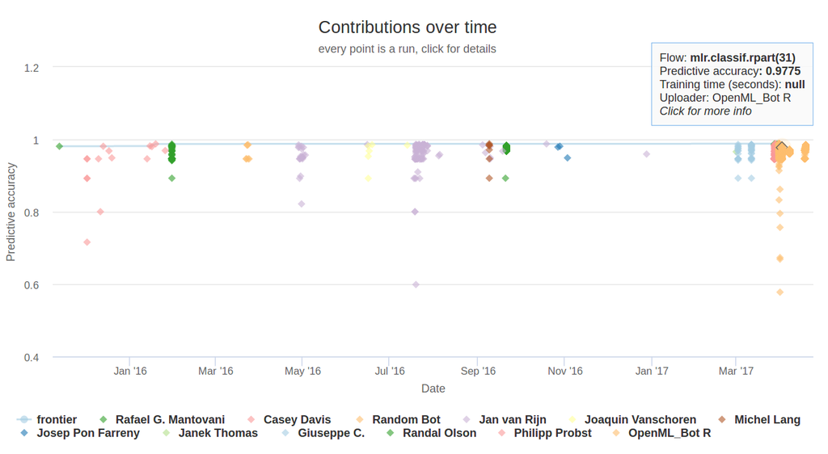

## For whom is OpenML?

- Domain scientists
- Data analysts
- Algorithm developers
- Students
- Teachers
- …

## OpenML with R

Run cforest on task 10 (https://www.openml.org/t/10)

```r
tsk.id <- 10
tsk <- getOMLTask(tsk.id)

lrn <- makeLearner("classif.cforest", ntree = 1000, mtry = 4)
run <- runTaskMlr(task = tsk, learner = lrn)
rn.id <- uploadOMLRun(run, confirm.upload = FALSE)
```

```r
evals <- listOMLRunEvaluations(task.id = tsk.id)
```

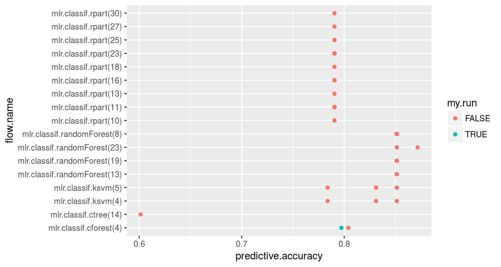

```r
mlrevals <- evals[grep("mlr", evals$flow.name), ]
mlrevals$my.run <- mlrevals$run.id == rn.id
ggplot(mlrevals, aes(x = predictive.accuracy,
                     y = flow.name,
                     color = my.run)) +
  geom_point()
```

## Checking a new algorithm

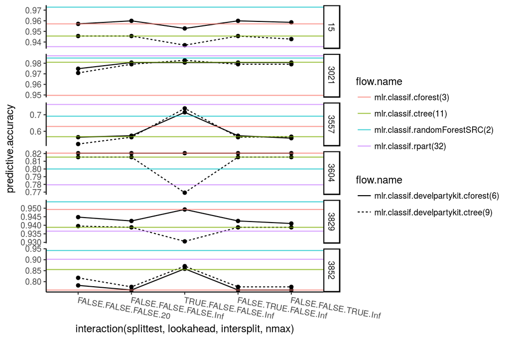

## Papers

G. Casalicchio, J. Bossek, M. Lang, D. Kirchhoff, P. Kerschke, B. Hofner, H. Seibold, J. Vanschoren, and B. Bischl.  
**OpenML: An R package to connect to the machine learning platform OpenML.**  
*Computational Statistics, 2017.*  
doi: 10.1007/s00180-017-0742-2.

J. Vanschoren, J. N. van Rijn, B. Bischl, and L. Torgo.  
**OpenML: Networked science in machine learning.**  
*SIGKDD Explorations, 15(2):49–60, 2014.*  
doi: 10.1145/2641190.2641198.

[figure not shown]

### Next OpenML workshop: 9 Oct – 13 Oct 2017

### Get in touch:

openmachinelearning@gmail.com, [@open_ml](https://twitter.com/open_ml)

## Backup slides

## ctree control parameters

**splittest**  
a logical changing linear (the default FALSE) to maximally selected statistics for variable selection. Currently needs testtype = "MonteCarlo".

**lookahead**  
a logical determining whether a split is implemented only after checking if tests in both daughter nodes can be performed.

**intersplit**  
a logical indicating if splits in numeric variables are simply x <= a (the default) or interpolated x <= (a + b) / 2. The latter feature is experimental, see Galili and Meilijson (2016).

**nmax**  
an integer defining the number of bins each variable is divided into prior to tree building. The default Inf does not apply any binning. Highly experimental, use at your own risk.

## Resources

General:

- [OpenML bootcamp](https://www.openml.org/guide/bootcamp)
- [Overview APIs + links to further resources](https://www.openml.org/guide/api)
- [Overview integrations + links to further resources](https://www.openml.org/guide/integrations)
- [Benchmarking with OpenML](https://www.openml.org/guide/benchmark)
- [Blog post on basic components](https://medium.com/open-machine-learning/basic-components-of-openml-a5745634c664)
- [Blog post on my first impression](http://heidiseibold.github.io/r/2016/05/02/OpenML/)

R:

- [These slides](http://openml.github.io/articles/slides/talk_cenisbs_2017/OpenML_CENISBS.html)
- [Tutorial at useR! 2017](http://openml.github.io/articles/slides/useR2017_tutorial/)
- [Blog post on parallel benchmarking](http://mlr-org.github.io/Parallel_benchmarking_with_OpenML_and_mlr/)